# Methane manuscript metagenomic analyses

Daniel Gregoire

# Workflow

1. Format the coverage and taxonomy data for creating heat maps (recreates File S1 from manuscript from which most figures in this notebook were generated)
2. Summarize metadata for the entire data set. 2.1 Min, max, mean, and median for coverage data (recreates Figure S2 from manuscript) 2.2 BBMap summary (recreates Table S1 from manuscript)
3. Methanogenic community analyses (recreates Figure 3 from manuscript) 3.1 Summarize methanogen metadata 3.2 Re-create DRAM output for methanogens
4. Methanotrophic community analyses (recreates Figure 5 from manuscript )

# Software and package versions

- Ran the sessionInfo() command on 2022-12-06 following Rstudio and R package updates

R version 4.1.2 (2021-11-01) Platform: x86_64-apple-darwin17.0 (64-bit) Running under: macOS Monterey 12.3.1

Matrix products: default LAPACK: /Library/Frameworks/R.framework/Versions/4.1/Resources/lib/libRlapack.dylib

locale: [1] en_CA.UTF-8/en_CA.UTF-8/en_CA.UTF-8/C/en_CA.UTF-8/en_CA.UTF-8

attached base packages: [1] stats graphics grDevices utils datasets methods base

other attached packages: [1] glue_1.6.2 patchwork_1.1.2 ggtext_0.1.2 data.table_1.14.6 forcats_0.5.2 stringr_1.5.0 dplyr_1.0.10 purrr_0.3.5  
[9] readr_2.1.3 tidyr_1.2.1 tibble_3.1.8 ggplot2_3.4.0 tidyverse_1.3.2

loaded via a namespace (and not attached): [1] Rcpp_1.0.9 lubridate_1.9.0 assertthat_0.2.1 digest_0.6.30 utf8_1.2.2 R6_2.5.1 cellranger_1.1.0  
[8] backports_1.4.1 reprex_2.0.2 evaluate_0.18 httr_1.4.4 pillar_1.8.1 rlang_1.0.6 googlesheets4_1.0.1 [15] readxl_1.4.1 rstudioapi_0.14 jquerylib_0.1.4 rmarkdown_2.18 textshaping_0.3.6 labeling_0.4.2 googledrive_2.0.0  
[22] gridtext_0.1.5 munsell_0.5.0 broom_1.0.1 compiler_4.1.2 modelr_0.1.10 xfun_0.35 systemfonts_1.0.4  
[29] pkgconfig_2.0.3 htmltools_0.5.3 tidyselect_1.2.0 fansi_1.0.3 crayon_1.5.2 tzdb_0.3.0 dbplyr_2.2.1  
[36] withr_2.5.0 commonmark_1.8.1 grid_4.1.2 jsonlite_1.8.4 gtable_0.3.1 lifecycle_1.0.3 DBI_1.1.3  
[43] magrittr_2.0.3 scales_1.2.1 cli_3.4.1 stringi_1.7.8 cachem_1.0.6 farver_2.1.1 fs_1.5.2  
[50] xml2_1.3.3 bslib_0.4.1 ellipsis_0.3.2 ragg_1.2.4 generics_0.1.3 vctrs_0.5.1 RColorBrewer_1.1-3 [57] tools_4.1.2 markdown_1.4 hms_1.1.2 fastmap_1.1.0 yaml_2.3.6 timechange_0.1.1 colorspace_2.0-3  
[64] gargle_1.2.1 rvest_1.0.3 knitr_1.41 haven_2.5.1 sass_0.4.4

# 1. Format the coverage and taxonomy data for creating heat maps

Currently, there is no way to re-organize the data in the DRAM distillate, which goes by alphabetical order by default. There is also no way to separate objects based on taxonomy. What I want to do is parse out the coverage on each unique scaffold ID so that I can calculate the average coverage across all scaffolds assigned to a bin and use that as a proxy for abundance within a given sample.

1. Load in the tab-delimited file containing the annotation data output from DRAM as a dataframe.

```r
library(tidyverse)
library(data.table)
annotations<-fread("FileS2_DRAM_annotations_all_MAGs_names_redacted.tsv", sep = "\t", header = "auto")
```

[output not shown]

2. Within the annotation file, there is a ‘scaffold’ variable. This data is output from the binning step and contains information separated by ’_’ characters. Use base R language, calling function(x) and the specific position of the numeric value of interest in between [] to create 3 new variables called ‘NODE’, ‘length’, and ‘coverage’, following the naming convention set fort in the bin output.

```r
annotations$NODE = sapply(strsplit(annotations$scaffold, "_"), function(x) x[2]) #keep this as a character
annotations$length = sapply(strsplit(annotations$scaffold, "_"), function(x) x[4]) #convert this to numeric
annotations$coverage = sapply(strsplit(annotations$scaffold, "_"), function(x) x[6]) #convert this to numeric
```

**Note:** The only option I have been able to get to work so far is by manually calling out the order of character strings I want in the ‘scaffold’ variable. I am sure there are more elegant solutions involving regular expressions that could be found by going through this resource (https://stackoverflow.com/questions/49900323/separate-string-after-last-underscore), but this gets the job done. Obtained this solution from: https://stackoverflow.com/questions/49900323/separate-string-after-last-underscore.

3. Make sure to recode the coverage and length variables as numeric variables since they may both be used to re-organize data.

```r
annotations$coverage<-as.numeric(annotations$coverage)
annotations$length<-as.numeric(annotations$length)
```

4. Rename the original file naming convention so it is more intuitive with the letters used to refer to landfill cells.

```r
annotations<- annotations %>% mutate(Sample_site = case_when(grepl("STA_", annotations$`fasta`) ~ "A",
                                                               grepl("STB_", annotations$`fasta`) ~ "B",
                                                               grepl("STC_", annotations$`fasta`) ~ "C",
                                                               grepl("STCSWMC_", annotations$`fasta`) ~ "CSWMC",
                                                               grepl("STD1_", annotations$`fasta`)~ "D1",
                                                               grepl("STD2_", annotations$`fasta`)~ "D2",
                                                               grepl("STE_", annotations$`fasta`)~ "E",
                                                               grepl("STF1_", annotations$`fasta`)~ "F1",
                                                               grepl("STF2_", annotations$`fasta`)~ "F2"))
```

5. As a sanity check, calculate how many unique NODE observations there are per bin. This should give you your total number of bins and line up with the product.html file step output from DRAM (in this case it is 1,881 MAGs).

```r
unique_NODE<-annotations %>% group_by(fasta) %>% summarise(count = n_distinct(NODE)) #this n_distinct command counts the distinct observations
```

6. Filter data set to unique values for the NODE variable. Check how many unique NODE IDs there for a given landfill cell (cell A has 93, for reference). It is crucial to **keep all variables** to maintain the ‘genome’ variable that contains the binIDs, which will be used to link this file to coverage and taxonomy data downstream to produce heat maps.

```r
annotations_distinct_only<-annotations %>% group_by(fasta) %>% distinct(NODE, .keep_all = TRUE)
annotations_distinct_only %>% group_by(fasta) %>% summarise(count = n_distinct(NODE)) %>% rename(genome = fasta)
```

| genome | count |
| --- | --- |
| STA_1 | 23 |
| STA_10 | 61 |
| STA_11 | 361 |
| STA_12 | 23 |
| STA_13 | 565 |
| STA_14 | 165 |
| STA_15 | 127 |
| STA_16 | 21 |
| STA_17 | 51 |
| STA_18 | 54 |

[output cut: 990 more lines]

```r
#rename the 'fasta' variable to 'genome' to make sure there is parallel naming between the different files coming from DRAM + GTDB
```

**Note:** I noticed that this step is outputing 1846 rows, instead of the 1881 it should be. We’re losing bins somewhere. When I added the group_by(fasta) argument, it made sure to keep all the fasta files and we end up with the proper number of rows. It must have been that maybe there were some duplicate NODE IDs spread out across other bins, but because these weren’t grouped by the bin ID they were getting erased.

7. Calculate the mean coverage across the unique NODE identifiers within a bin now.

```r
annotations_distinct_only_means<-annotations_distinct_only %>%
                                   group_by(fasta) %>%
                                   summarise(mean_coverage_bin = mean(coverage)) %>%
                                   rename(genome = fasta)

head(annotations_distinct_only_means) #quick sanity check
```

| genome | mean_coverage_bin |
| --- | --- |
| STA_1 | 8.932660 |
| STA_10 | 5.882275 |
| STA_11 | 2.578845 |
| STA_12 | 5.872824 |
| STA_13 | 3.027842 |
| STA_14 | 2.295591 |

8. Load the taxonomy data into R and take note of any formatting issues that may cause problems downstream.

```r
library(tidyverse)
library(data.table)
taxonomy<-fread("Methane_manuscript_GTDB_classifications", sep = "auto", header = FALSE)
taxonomy_parsed<- separate(taxonomy, V1, into = c("genome", "Kingdom"), sep = " (?=[^ ]+$)")  #this command is to parse the character string
taxonomy_parsed$genome<-trimws(taxonomy_parsed$genome, which = c("right")) #need to trim the white space on the right side of the bin IDs
taxonomy_parsed<- taxonomy_parsed %>%
  rename(Phylum = V2) %>%
  rename(Class = V3) %>%
  rename(Order = V4) %>%
  rename(Family = V5) %>%
  rename(Genus = V6) %>%
  rename(Species = V7)
```

9. Rename the bin IDs to something more intuitive with how the landfill is organized using the ‘case_when’ argument to define multiple arguments.

```r
taxonomy_parsed<- taxonomy_parsed %>% mutate(Sample_site = case_when(grepl("STA_", taxonomy_parsed$`genome`) ~ "A",
                                                               grepl("STB_", taxonomy_parsed$`genome`) ~ "B",
                                                               grepl("STC_", taxonomy_parsed$`genome`) ~ "C",
                                                               grepl("STCSWMC_", taxonomy_parsed$`genome`) ~ "CSWMC",
                                                               grepl("STD1_", taxonomy_parsed$`genome`)~ "D1",
                                                               grepl("STD2_", taxonomy_parsed$`genome`)~ "D2",
                                                               grepl("STE_", taxonomy_parsed$`genome`)~ "E",
                                                               grepl("STF1_", taxonomy_parsed$`genome`)~ "F1",
                                                               grepl("STF2_", taxonomy_parsed$`genome`)~ "F2"))
```

10.Load the product.tsv file from DRAM that is used to create the heat map .html file output sorted alphabetically by default in DRAM. It is important to use the ‘fread’ package here, which is a table reading package that helps conserve special characters in column names (this will be important for maintaining the pathway names as they are output by DRAM).

**Note:** Use the product_v_1_20.tsv in the directory dedicated to DRAM v1.20 outputs since this includes all bins

```r
library(tidyverse)
library(data.table)
product<-fread("Methane_manuscript_DRAM_product.tsv", sep = "\t", header = "auto")
#using the fread package here helps conserve the special characters in the pathway names
head(product)
```

| genome | 3-Hydroxypropionate bi-cycle | Acetyl-CoA pathway, CO2 => acetyl-CoA | Citrate cycle (TCA cycle, Krebs cycle) | Dicarboxylate-hydroxybutyrate cycle | Entner-Doudoroff pathway, glucose-6P => glyceraldehyde-3P + pyruvate | Glycolysis (Embden-Meyerhof pathway), glucose => pyruvate | Glyoxylate cycle | Hydroxypropionate-hydroxybutylate cycle | Methanogenesis, CO2 => methane | Pentose phosphate pathway (Pentose phosphate cycle) | Reductive acetyl-CoA pathway (Wood-Ljungdahl pathway) | Reductive citrate cycle (Arnon-Buchanan cycle) | Reductive pentose phosphate cycle (Calvin cycle) | Complex I: NAD(P)H:quinone oxidoreductase, chloroplasts and cyanobacteria | Complex I: NADH dehydrogenase (ubiquinone) 1 alpha subcomplex | Complex I: NADH:quinone oxidoreductase, prokaryotes | Complex II: Fumarate reductase, prokaryotes | Complex II: Succinate dehydrogenase (ubiquinone) | Complex II: Succinate dehydrogenase, prokaryotes | Complex III: Cytochrome bc1 complex | Complex III: Cytochrome bc1 complex respiratory unit | Complex III: Cytochrome bd ubiquinol oxidase | Complex IV High affinity: Cytochrome bd ubiquinol oxidase | Complex IV High affinity: Cytochrome c oxidase, cbb3-type | Complex IV Low affinity: Cytochrome aa3-600 menaquinol oxidase | Complex IV Low affinity: Cytochrome c oxidase | Complex IV Low affinity: Cytochrome c oxidase, prokaryotes | Complex IV Low affinity: Cytochrome o ubiquinol oxidase | Complex V: F-type ATPase, eukaryotes | … |
| --- | --- | --- | --- | --- | --- | --- | --- | --- | --- | --- | --- | --- | --- | --- | --- | --- | --- | --- | --- | --- | --- | --- | --- | --- | --- | --- | --- | --- | --- | --- |
| STA_1 | 0.00 | 0 | 0.750 | 0.38461538 | 0.00 | 0.5555556 | 0.4 | 0.0000000 | 0.000 | 0.7142857 | 0.1428571 | 0.9 | 0.7272727 | 0.00000000 | 0 | 0.6428571 | 0 | 0 | 0.5 | 0.2 | 0.6666667 | 0 | 0 | 0.6666667 | 0 | 0.0 | 0 | 0 | 0 | … |
| STA_10 | 0.00 | 0 | 0.000 | 0.07692308 | 0.25 | 0.5555556 | 0.0 | 0.0000000 | 0.000 | 0.2857143 | 0.0000000 | 0.1 | 0.3636364 | 0.00000000 | 0 | 0.0000000 | 0 | 0 | 0.0 | 0.0 | 0.0000000 | 0 | 0 | 0.0000000 | 0 | 0.0 | 0 | 0 | 0 | … |
| STA_11 | 0.00 | 1 | 0.375 | 0.38461538 | 0.25 | 0.7777778 | 0.0 | 0.2142857 | 0.125 | 0.7142857 | 0.2857143 | 0.5 | 0.5454545 | 0.09090909 | 0 | 0.7142857 | 0 | 0 | 0.0 | 0.0 | 0.0000000 | 0 | 0 | 0.0000000 | 0 | 0.0 | 0 | 0 | 0 | … |
| STA_12 | 0.00 | 0 | 0.875 | 0.38461538 | 0.00 | 0.6666667 | 0.6 | 0.0000000 | 0.000 | 0.7142857 | 0.1428571 | 0.9 | 0.7272727 | 0.00000000 | 0 | 0.7142857 | 0 | 0 | 0.5 | 0.3 | 1.0000000 | 0 | 0 | 0.6666667 | 0 | 0.0 | 0 | 0 | 0 | … |
| STA_13 | 0.25 | 0 | 0.875 | 0.38461538 | 0.75 | 0.6666667 | 0.6 | 0.0000000 | 0.375 | 1.0000000 | 0.1428571 | 0.6 | 0.6363636 | 0.00000000 | 0 | 0.4166667 | 0 | 0 | 1.0 | 0.3 | 1.0000000 | 1 | 1 | 0.0000000 | 0 | 0.2 | 1 | 0 | 0 | … |
| STA_14 | 0.00 | 0 | 0.375 | 0.15384615 | 0.00 | 0.4444444 | 0.0 | 0.0000000 | 0.000 | 0.7142857 | 0.1428571 | 0.3 | 0.4545455 | 0.00000000 | 0 | 0.0000000 | 0 | 0 | 0.0 | 0.0 | 0.0000000 | 0 | 0 | 0.0000000 | 0 | 0.0 | 0 | 0 | 0 | … |

11. Rename the bin IDs to something more intuitive with how the landfill is organized using the ‘case_when’ argument to define multiple arguments.

```r
product<- product %>% mutate(Sample_site = case_when(grepl("STA_", product$`genome`) ~ "A",
                                                               grepl("STB_", product$`genome`) ~ "B",
                                                               grepl("STC_", product$`genome`) ~ "C",
                                                               grepl("STCSWMC_", product$`genome`) ~ "CSWMC",
                                                               grepl("STD1_", product$`genome`)~ "D1",
                                                               grepl("STD2_", product$`genome`)~ "D2",
                                                               grepl("STE_", product$`genome`)~ "E",
                                                               grepl("STF1_", product$`genome`)~ "F1",
                                                               grepl("STF2_", product$`genome`)~ "F2"))
```

12. Left join the coverage data, the taxonomy data, and the product.tsv file by the ‘genome’ variable. This will act as your master data frame from which you carry out all subsequent data manipulation steps

```r
joint_file <- annotations_distinct_only_means %>%
              left_join(product, by ="genome") %>%
              left_join(taxonomy_parsed, by ="genome") %>%
              select(-Sample_site.x) %>% #remove the duplicated Sample_site variable
              rename(Sample_site = Sample_site.y)
```

At this point, you should have 1881 observations still, which is the total number of bins that went through DRAM.

13. Create a new variable that combined the genome bin ID, phylum and family information into one. This will be used as the new variable to identify the bins along the y-axis and will help keep your code clean instead of adding new information into the plotting script.

```r
joint_file$phylum_family_genome<-paste(paste(paste(joint_file$Phylum, ",", joint_file$Family), "(",joint_file$genome),")")
joint_file$family_genus_genome<-paste(paste(paste(joint_file$Family, ",", joint_file$Genus), "(",joint_file$genome),")")
joint_file$genus_species_genome<-paste(paste(paste(joint_file$Genus, ",", joint_file$Species), "(",joint_file$genome),")")
```

14. This part of the workflow effectively recreates File S1 associated with the manuscript. Write .tsv file to upload with manuscript for reproducibility.

```r
write.table(joint_file, file = "FileS1_DRAM_product_connected_GTDB_taxonomy.tsv", sep ='\t', row.names = FALSE)
```

# 2. Summarize metadata for the entire dataset

Now that we have created File S1 from which most of the figures can be generated, try loading that file here rather than having to run the upstream code.

## 2.1 min, max, mean, and median for coverage data

1. Run summary functions in the ‘dplyr’ package to count the number of bins per sample site.

```r
joint_file<-fread("FileS1_DRAM_product_connected_GTDB_taxonomy.tsv", sep = "\t", header = "auto")
bin_count<- joint_file  %>% group_by(Sample_site) %>% summarise(no_rows =length(genome)) %>% rename(number_of_bins = no_rows)
```

2. Use summary functions to extract min, max, mean, and median coverage data at each sample site.

```r
Coverage_summary<- joint_file %>%
                   group_by(Sample_site) %>%
                   summarize(min_coverage_site = min(mean_coverage_bin),
                             max_coverage_site = max(mean_coverage_bin),
                             mean_coverage_site = mean(mean_coverage_bin),
                             median_coverage_site = median(mean_coverage_bin)) #%>%
                   #filter(!Sample_site == "CSWMC") the water treatment plan can be filtered removing the # from these lines of code

Coverage_summary_no_CSWMC<- joint_file %>%
                   group_by(Sample_site) %>%
                   summarize(min_coverage_site = min(mean_coverage_bin),
                             max_coverage_site = max(mean_coverage_bin),
                             mean_coverage_site = mean(mean_coverage_bin),
                             median_coverage_site = median(mean_coverage_bin)) %>%
                    filter(!Sample_site == "CSWMC")


#export the file if you want
write.table(Coverage_summary, file = "Genomic_coverage_summary.tsv", sep = "\t")

#making this ordered variable is essential to overlaying the mean and median in the density plot
#don't want it in the exported table, which is why it comes after that command
Coverage_summary$Sample_site_ordered = factor(Coverage_summary$Sample_site,
                                          levels =c("A", "B", "C", "D1", "D2", "E","F1", "F2","CSWMC"))

Coverage_summary_no_CSWMC$Sample_site_ordered = factor(Coverage_summary_no_CSWMC$Sample_site,
                                          levels =c("A", "B", "C", "D1", "D2", "E","F1", "F2","CSWMC"))
```

3. Create faceted density plots to visualize the coverage data and create Figure S2 from the manuscript.

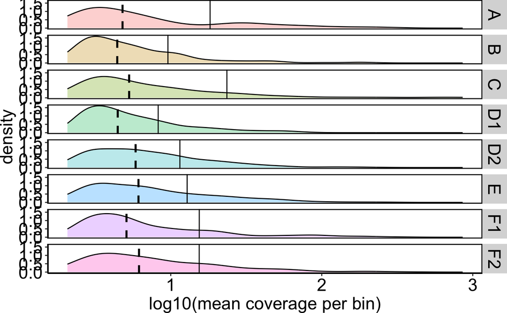

```r
joint_file$Sample_site_ordered = factor(joint_file$Sample_site,
                                          levels =c("A", "B", "C", "D1", "D2", "E","F1", "F2","CSWMC"))

density_plot_theme <- theme(panel.grid.major = element_blank(), panel.grid.minor = element_blank(),
                     panel.background = element_blank(), axis.line = element_line(colour = "black"),
                     axis.text.x = element_text(color = "black", size = 18),
                     axis.text.y = element_text(color = "black", size = 18),
                     axis.title.x = element_text(color = "black", size = 18),
                     axis.title.y = element_text(color = "black", size = 18),
                     strip.text.x = element_text(color = "black", size = 18),
                     strip.text.y = element_text(color = "black", size = 18),
                     legend.title=element_text(size=16),
                     legend.text=element_text(size=14),
                     legend.key = element_rect(fill = "white", color = NA),
                     plot.title = element_text(size = 18, face = "bold", hjust = 0.5),
                     panel.border = element_rect(colour = "black", fill=NA, size=1),
                     plot.margin = unit(c(0, 0, 0, 0), "cm"))
Density_genomic_coverage_facet<- joint_file %>% #work from the raw data
                           filter(!Sample_site == "CSWMC") %>% #remove the water treatment plant for the summary figures to correspond to manuscript
                           ggplot(aes(x=log10(mean_coverage_bin), fill=Sample_site_ordered)) +
                           geom_density(alpha=.3) +
                           geom_vline(data = Coverage_summary_no_CSWMC, aes(xintercept=log10(mean_coverage_site))) +
                           geom_vline(data = Coverage_summary_no_CSWMC,
                                      aes(xintercept=log10(median_coverage_site)), linetype="dashed", size=1)+
                           facet_grid(rows = "Sample_site_ordered", scales = "fixed")  +
                           xlab("log10(mean coverage per bin)") +
                           density_plot_theme +
                           theme(legend.position = "none")
Density_genomic_coverage_facet

#combined_plot_phylum
ggsave("FigS2_Genomic_coverage_density_plots_facets_mean_median.pdf", height=20, width=5, device="pdf")
```

## 2.2 BBMap summary

1. Bring the assembly stats created with BBMap contained in the “Methane_manuscript_curated_assembly_stats.txt” file into R to see how they look.

```r
library(tidyverse)
library(data.table)
Curated_assembly_stats<-read.delim("Methane_manuscript_curated_assembly_stats.txt", sep = "\t", header = TRUE)
head(Curated_assembly_stats)
```

|  | Sample_site | X.n_scaffolds | n_contigs | scaf_bp | contig_bp | gap_pct | scaf_N50 | scaf_L50 | ctg_N50 | ctg_L50 | scaf_N90 | scaf_L90 | ctg_N90 | ctg_L90 | scaf_max | ctg_max | scaf_n_gt50K | scaf_pct_gt50K | gc_avg | gc_std |
| --- | --- | --- | --- | --- | --- | --- | --- | --- | --- | --- | --- | --- | --- | --- | --- | --- | --- | --- | --- | --- |
| 1 | A | 1045056 | 1057598 | 2187507397 | 2187222859 | 0.013 | 222268 | 2059 | 226000 | 2042 | 837577 | 1103 | 844225 | 1099 | 1549695 | 1549695 | 1300 | 6.654 | 0.49557 | 0.11232 |
| 2 | B | 1178240 | 1189387 | 2563275916 | 2562912344 | 0.014 | 241957 | 2202 | 246212 | 2186 | 798878 | 1208 | 805763 | 1204 | 1566446 | 1566446 | 1399 | 6.363 | 0.47054 | 0.10202 |
| 3 | C | 928453 | 941344 | 2133304492 | 2132958946 | 0.016 | 175702 | 2428 | 179645 | 2399 | 727452 | 1132 | 735641 | 1126 | 1317511 | 1096538 | 1384 | 7.285 | 0.48456 | 0.12012 |
| 4 | CSWMC | 983256 | 990919 | 2326144651 | 2325687551 | 0.020 | 184419 | 2581 | 188617 | 2561 | 765427 | 1146 | 771565 | 1144 | 693676 | 693676 | 1289 | 4.975 | 0.43531 | 0.10319 |
| 5 | D1 | 1518081 | 1531198 | 3165343725 | 3164934022 | 0.013 | 339687 | 2083 | 344467 | 2070 | 665057 | 1490 | 672350 | 1483 | 1165709 | 1165709 | 1322 | 4.581 | 0.46437 | 0.10489 |
| 6 | D2 | 1067682 | 1082203 | 2732952921 | 2732344116 | 0.022 | 173726 | 2938 | 179307 | 2896 | 573668 | 1443 | 582565 | 1435 | 783932 | 533201 | 2311 | 7.950 | 0.43391 | 0.10683 |

2. Reformat the table so it has more meaningful names for the columns and export in .tsv format to generate **Table S1** from the manuscript. Left-join to the data frame containing coverage summaries generated in Section 2.1 step 2.

```r
Curated_assembly_stats_renamed<- Curated_assembly_stats %>%
                                 rename(`Number of scaffolds` = X.n_scaffolds) %>%
                                 rename(`Number of contigs` = n_contigs) %>%
                                 rename(`Total scaffold length (bp)` = scaf_bp) %>%
                                 rename(`Total contig length (bp)` = contig_bp) %>%
                                 rename(`Gap percent` = gap_pct) %>%
                                 rename(`N50 for scaffolds` = scaf_N50) %>%
                                 rename(`L50 for scaffolds` = scaf_L50) %>%
                                 rename(`N50 for contigs` = ctg_N50) %>%
                                 rename(`L50 for contigs` = ctg_L50) %>%
                                 rename(`N90 for scaffolds` = scaf_N90) %>%
                                 rename(`L90 for scaffolds` = scaf_L90) %>%
                                 rename(`N90 for contigs` = ctg_N90) %>%
                                 rename(`L90 for contigs` = ctg_L90) %>%
                                 rename(`Maximum scaffold length (bp)` = scaf_max) %>%
                                 rename(`Maximum contig length (bp)` = ctg_max) %>%
                                 rename(`Sequence count for scaffolds >50 KB` = scaf_n_gt50K) %>%
                                 rename(`Sequence size percentage for scaffolds >50 KB` = scaf_pct_gt50K) %>%
                                 rename(`Average GC content` = gc_avg) %>%
                                 rename(`Standard deviation for GC content` = gc_std) %>%
                                 select(Sample_site, everything()) %>%
                                 left_join(Coverage_summary) %>%
                                 rename(`Minimum coverage for single MAG` = min_coverage_site) %>%
                                 rename(`Maximum coverage for single MAG` = max_coverage_site) %>%
                                 rename(`Mean coverage for all MAGs` = mean_coverage_site) %>%
                                 rename(`Median coverage for all MAGs` = median_coverage_site) %>%
                                 rename(`Sample site` = Sample_site) %>%
                                 select(-(Sample_site_ordered))
write.table(Curated_assembly_stats_renamed, file = "TableS1_BBMap_coverage_summary.tsv", sep ='\t', row.names = FALSE)
```

# 3. Methanogenic community analyses

1. Create heatmap themes upfront to facilitate formatting the data visualizations.

```r
heatmap_theme<- theme(panel.grid.major = element_blank(), panel.grid.minor = element_blank(),
               panel.background = element_blank(), axis.line = element_line(colour = "black"),
               axis.text.x = element_text(color = "black", size = 14),
               axis.text.y = element_text(color = "black", size = 14),
               axis.title.x = element_text(color = "black", size = 16, vjust = -3),
               axis.title.y = element_text(color = "black", size = 16, vjust = 6),
               legend.title=element_text(size=16),
               legend.text=element_text(size=14),
               legend.key = element_rect(fill = "white", color = NA),
               plot.title = element_text(size = 18, face = "bold", hjust = 0.5),
               panel.border = element_rect(colour = "black", fill=NA, size=1),
               plot.margin = unit(c(0, 0, 0, 0), "cm"))
```

**Background**: To examine the methanogenic community from the landfill, we’ve developed the following criteria to identify putative methanogen MAGs in the the joint_file data frame:

- A TRUE hit for the “Methanogenesis and methanotrophy: Key functional gene” in the presence absence data, which is a hit for the *mcrA* gene

AND/OR

- Completion of the “Methanogenesis, CO2 => methane” pathways that is >= to 87.5%. In DRAM, the hydrogenotrophic methanogenesis pathway require 8 steps that includes the 7 key enzymatic steps required for forward and reverse methanogenesis (no distinction) and the ability to use reduced ferredoxin as a source of reducing power.

This criteria was revised 2021-05-08 and re-applied to previous analysis to help captures MAGs that have the majority of the metabolioc potential required to carry out methanogenesis. The logic being that it is possible mcrA is occurring at the end of scaffolds despite other parts of the mcr operon assembling. DRAM does not register these as a TRUE for mcrA unless the alpha subunit of the methyl coenzyme M reductase is dectated (i.e. mcrA).

**Note**: All of the MAGs with 87.5% completion of the “Methanogenesis, CO2 => methane” but showing FALSE for the “Methanogenesis and methanotrophy: Key functional gene” were screened manually using the *annotations* data frame to confirm that at least one component of the mcr operon was detected via KEGG, and less so in Pfam due to the lower score (D grade).

## 3.1 Summarize methanogen metadata

1. As a first step, create a dedicated data frame using the criteria outlined in the Background section above. Based on previous analysis performed prior to 2021-05-08 we have decided to remove MAGs with the mcrA gene that were taxanomically classified to the Bacterial family Dysgonomnadaceae because a single genome assembly revealed that these MAGs were carrying the mcrA gene most likely due to a misbin. Following some additional manual curation using DRAM’s annotation and metabolism summary files, we will also be removing MAGs STB_81, STC_9, STD1_54, STD1_76, STD2_126, and STD2_203, all from the unnamed family UBA148 within the order Methanocellales. The reason for this is because none of these MAGs showed a single gene within the mcr operon, whereas other MAGs despite lacking the mcrA did (e.g. component A2, mcrC, and mcrD).

```r
#re-load File S1 if need be
joint_file<-fread("FileS1_DRAM_product_connected_GTDB_taxonomy.tsv", sep = "\t", header = "auto")

#trim to putative methanogen MAGs
methanogens <- joint_file %>%
               filter(`Methanogenesis and methanotrophy: Key functional gene` == TRUE |
                      `Methanogenesis, CO2 => methane` >= 0.875) %>%
               filter(!genome == "STCSWMC_52") %>% #Dysgonomanadaceae bin
               filter(!genome == "STF2_58") %>% #Dysgonomanadaceae bin
               filter(!genome == "STB_81") %>% #UBA148 here and for all MAGs below
               filter(!genome == "STC_9") %>%
               filter(!genome == "STD1_54") %>%
               filter(!genome == "STD1_76") %>%
               filter(!genome == "STD2_126") %>%
               filter(!genome == "STD2_203")
```

**Note:** Notably, none of the MAGs that were included in the data on the basis of >87.% complete hydrogenotrophic pathway alone displayed mcrB or mcrG, the two key genes for the enzyme. Instead, the manual analysis summarized in Evernote shows that its often component A2 (gene has no name), and/or mcrC and/or mcrD that shows up (not the strongest evidence).

2. Generate summary data to count putative methanogenic MAGs and their associated lineages.

```r
methanogen_bin_count<- methanogens %>% group_by(Sample_site) %>%
                       summarise(no_rows =length(genome)) %>%
                       rename(number_methanogen_bins = no_rows)
methanogen_coverage<- methanogens %>% group_by(Sample_site) %>% summarise(mean = mean(mean_coverage_bin))
methanogen_to_total_bin_count<-left_join(bin_count, methanogen_bin_count) %>%
                               mutate(Percent_methanogens = (number_methanogen_bins/number_of_bins) *100)
```

3. List the distinct family names and count how many families occur at the level of each landfill cell in the methanogen data set. This will help provide summary information in the results and discussion.

```r
Methanogen_family_list<- joint_file %>%
                         filter(`Methanogenesis and methanotrophy: Key functional gene` == TRUE |
                                `Methanogenesis, CO2 => methane` >= 0.875) %>%
                         filter(!genome == "STCSWMC_52") %>%
                         filter(!genome == "STF2_58") %>%
                         filter(!genome == "STB_81") %>% #UBA148 here and for all MAGs below
                         filter(!genome == "STC_9") %>%
                         filter(!genome == "STD1_54") %>%
                         filter(!genome == "STD1_76") %>%
                         filter(!genome == "STD2_126") %>%
                         filter(!genome == "STD2_203") %>%
                         distinct(Family) %>%
                         arrange(Family)


Methanogen_families<-joint_file %>%
                     filter(`Methanogenesis and methanotrophy: Key functional gene` == TRUE |
                            `Methanogenesis, CO2 => methane` >= 0.875) %>%
                     filter(!genome == "STCSWMC_52") %>%
                     filter(!genome == "STF2_58") %>%
                     filter(!genome == "STB_81") %>% #UBA148 here and for all MAGs below
                     filter(!genome == "STC_9") %>%
                     filter(!genome == "STD1_54") %>%
                     filter(!genome == "STD1_76") %>%
                     filter(!genome == "STD2_126") %>%
                     filter(!genome == "STD2_203") %>%
                     summarise(count = n_distinct(Family))

Methanogen_families_per_site <- joint_file %>%
                                filter(`Methanogenesis and methanotrophy: Key functional gene` == TRUE |
                                       `Methanogenesis, CO2 => methane` >= 0.875) %>%
                                filter(!genome == "STCSWMC_52") %>%
                                filter(!genome == "STF2_58") %>%
                                filter(!genome == "STB_81") %>% #UBA148 here and for all MAGs below
                                filter(!genome == "STC_9") %>%
                                filter(!genome == "STD1_54") %>%
                                filter(!genome == "STD1_76") %>%
                                filter(!genome == "STD2_126") %>%
                                filter(!genome == "STD2_203") %>%
                                group_by(Sample_site, Family) %>%
                                summarise(no_rows =length(genome)) %>%
                                group_by(Sample_site) %>%
                                arrange(Family) %>%
                                arrange(Sample_site)
```

## 3.2 Re-create DRAM output for methanogens

1. Create two data frames: 1_ the percent_gathered that encompasses how complete metabolic pathways are and 2) the true_false_gathered that provides gene presence/absence data as shown in DRAM using the data set comprised of putative methanogenic MAGs.

```r
methanogens_percent_complete_gathered<-methanogens %>%
                           gather(key = Pathway_name, value = Percent_complete,
                                  "3-Hydroxypropionate bi-cycle":"Complex V: V/A-type ATPase, prokaryotes", na.rm=FALSE) %>%
                           select(-c("CAZy: Alpha-galactans": "Sample_site")) %>%
                           mutate(group = case_when(grepl("\\:.*", Pathway_name) ~
                           sub("\\:.*", "", Pathway_name),
                           !grepl("\\:.*", Pathway_name) ~ "Module")) %>% #maintained up to this step
                           mutate(Pathway_name = gsub("Complex I*:","",Pathway_name)) %>% #had to be more specific in filtering
                           mutate(Pathway_name = gsub("Complex IV*.*:","",Pathway_name)) %>%
                           mutate(Pathway_name = gsub("Complex V*.*:","",Pathway_name)) %>%
                           left_join(taxonomy_parsed, by = "genome") #re-add the taxonomic information here


methanogens_true_false_gathered<- methanogens %>%
                      gather(Pathway_name, Presence_absence,
                             "CAZy: Alpha-galactans":"Sulfur metabolism: thiosulfate => sulfite", na.rm = FALSE) %>%
                      select(-c("3-Hydroxypropionate bi-cycle":"Complex V: V/A-type ATPase, prokaryotes")) %>%
                      mutate(group = case_when(grepl("\\:.*", Pathway_name) ~
                           sub("\\:.*", "", Pathway_name))) %>%
                      mutate(Pathway_name = gsub(".*:","",Pathway_name))
```

2. Re-define the order you want the variables to appear in for the quantitative and categorical data using the methanogen data frame. I have provided the names of facets output by DRAM with in-line comments denoted by #.

```r
#Quantitative data script
methanogens_percent_complete_gathered$Pathway_name<-trimws(methanogens_percent_complete_gathered$Pathway_name, which = c("left"))

methanogens_percent_complete_gathered$Pathway_name = factor(methanogens_percent_complete_gathered$Pathway_name,
                                          levels =c(

                                          #Module facet

                                          "Glycolysis (Embden-Meyerhof pathway), glucose => pyruvate",
                                          "Pentose phosphate pathway (Pentose phosphate cycle)",
                                          "Entner-Doudoroff pathway, glucose-6P => glyceraldehyde-3P + pyruvate",
                                          "Citrate cycle (TCA cycle, Krebs cycle)",
                                          "Glyoxylate cycle",
                                          "Reductive pentose phosphate cycle (Calvin cycle)",
                                          "Reductive citrate cycle (Arnon-Buchanan cycle)",
                                          "Dicarboxylate-hydroxybutyrate cycle",
                                          "Hydroxypropionate-hydroxybutylate cycle",
                                          "3-Hydroxypropionate bi-cycle",
                                          "Reductive acetyl-CoA pathway (Wood-Ljungdahl pathway)",
                                          "Acetyl-CoA pathway, CO2 => acetyl-CoA",
                                          "Methanogenesis, CO2 => methane",

                                          #Complex I

                                          "NADH:quinone oxidoreductase, prokaryotes",
                                          "NAD(P)H:quinone oxidoreductase, chloroplasts and cyanobacteria",
                                          "NADH dehydrogenase (ubiquinone) 1 alpha subcomplex",

                                          #Complex II

                                          "Succinate dehydrogenase (ubiquinone)",
                                          "Succinate dehydrogenase, prokaryotes",
                                          "Fumarate reductase, prokaryotes",

                                          #Complex III

                                          "Cytochrome bc1 complex respiratory unit", #what's the difference between first and second?
                                          "Cytochrome bc1 complex",
                                          "Cytochrome bd ubiquinol oxidase",

                                          #Complex IV high affinity

                                          #"Cytochrome bd ubiquinol oxidase", This level is being duplicated, but may not be an issue
                                          "Cytochrome c oxidase, cbb3-type",

                                          #Complex IV low affinity

                                          "Cytochrome c oxidase",
                                          "Cytochrome c oxidase, prokaryotes",
                                          "Cytochrome aa3-600 menaquinol oxidase",
                                          "Cytochrome o ubiquinol oxidase",

                                          #Complex V
                                          "F-type ATPase, prokaryotes and chloroplasts",
                                          "F-type ATPase, eukaryotes",
                                          "V/A-type ATPase, prokaryotes",
                                          "V-type ATPase, eukaryotes"
                                          ))

#Categorical data script
methanogens_true_false_gathered$Pathway_name<-trimws(methanogens_true_false_gathered$Pathway_name, which = c("left"))

methanogens_true_false_gathered$Pathway_name = factor(methanogens_true_false_gathered$Pathway_name,
                                          levels =c(

                                          #CAZy facet

                                          "Polyphenolics",
                                          "Crystalline Cellulose",
                                          "Amorphous Cellulose",
                                          "Xyloglucan",
                                          "Xylans",
                                          "Alpha-mannan",
                                          "Beta-mannan",
                                          "Mixed-Linkage glucans",
                                          "Starch",
                                          "Pectin",
                                          "Arabinan",
                                          "Alpha-galactans",
                                          "Beta-galactan (pectic galactan)",
                                          "Chitin",
                                          "Sulf-Polysachharides",
                                          "Mucin",
                                          "Fucose Cleavage",
                                          "Arabinose cleavage",
                                          "Rhamnose cleavage",

                                          #Nitrogen metabolism

                                          "ammonia => nitrite",
                                          "Bacterial/Archaeal ammonia oxidation",
                                          "Bacterial (aerobic-specific) ammonia oxidation",
                                          "Bacterial (anaerobic-specific) ammonia oxidation",
                                          "nitrite => nitrate",
                                          "nitrate => nitrite",
                                          "nitrite => nitric oxide",
                                          "Dissimilatory nitrite reduction to ammonia (DNRA)",
                                          "nitric oxide => nitrous oxide",
                                          "nitrous oxide => nitrogen",
                                          "nitrogen => ammonia",
                                          "Nitrogen fixation altennative",

                                          #Sulfur metabolism
                                          "dissimilatory sulfate reduction (and oxidation) sulfate => sulfide",
                                          "thiosulfate => sulfite",
                                          "Thiosulfate oxidation by SOX complex, thiosulfate => sulfate",
                                          "tetrathionate => thiosulfate",

                                          #Other reductases

                                          "selenate/Chlorate reduction",
                                          "TMAO reductase",
                                          "mercury reduction",
                                          "arsenate reduction, pt 1",
                                          "arsenate reduction, pt 2",

                                          #Photosynthesis
                                          "Photosystem I",
                                          "Photosystem II",

                                          #Methanogenesis and methanotrophy

                                          "Key functional gene",
                                          "acetate => methane, pt 1",
                                          "acetate => methane, pt 2",
                                          "acetate => methane, pt 3",
                                          "methanol => methane",
                                          "trimethylamine => dimethylamine",
                                          "dimethylamine => monomethylamine",
                                          "monomethylamine => ammonia",
                                          "putative but not defining CO2 => methane",
                                          "methane => methanol, with oxygen (pmo)",
                                          "methane => methanol, with oxygen (mmo)",

                                          #SCFA and alcohol conversions
                                          "pyruvate => acetyl CoA v1",
                                          "pyruvate => acetyl CoA v2",
                                          "pyruvate => acetylCoA f+ formate v3",
                                          "acetate, pt 1",
                                          "acetate, pt 2",
                                          "acetate, pt 3",
                                          "lactate L",
                                          "lactate D",
                                          "Butyrate, pt 1",
                                          "Butyrate, pt 2",
                                          "Propionate, pt 1",
                                          "Propionate, pt 2",
                                          "Alcohol production"
                                          ))
```

3. Combine the *methanogens_percent_complete_gathered* and *methanogens_true_false_gathered* data frames to re-create DRAM’s output, focusing on the most salient data for methanogenesis.

```r
library(tidyverse)
library(ggtext)
library(patchwork)
library(glue)

heatmap_theme<- theme(panel.grid.major = element_blank(), panel.grid.minor = element_blank(),
               panel.background = element_blank(), axis.line = element_line(colour = "black"),
               axis.text.x = element_text(color = "black", size = 14),
               axis.text.y = element_text(color = "black", size = 14),
               axis.title.x = element_text(color = "black", size = 16, vjust = -3),
               axis.title.y = element_text(color = "black", size = 16, vjust = 6),
               legend.title=element_text(size=16),
               legend.text=element_text(size=14),
               legend.key = element_rect(fill = "white", color = NA),
               plot.title = element_text(size = 18, face = "bold", hjust = 0.5),
               panel.border = element_rect(colour = "black", fill=NA, size=1),
               plot.margin = unit(c(0, 0, 0, 0), "cm"))

methanogens_percent_complete_gathered$Sample_site = factor(methanogens_percent_complete_gathered$Sample_site,
                                          levels =c("A", "B", "C", "D1", "D2", "E","F1", "F2","CSWMC")) #orders sites that will act as rows in facet


methanogens_percent_complete_heatmap_pathways_refined<- methanogens_percent_complete_gathered %>%
                    filter(!Sample_site == "CSWMC") %>%
                    filter(Pathway_name == "Acetyl-CoA pathway, CO2 => acetyl-CoA" |
                           Pathway_name == "Methanogenesis, CO2 => methane") %>%
                    #reformat the names so they are better for presentation purposes, making sure to start with order
                    mutate(Order = str_replace(string = Order,
                                                pattern = "o__",
                                                replacement = "")) %>%
                    mutate(Order = str_replace(string = Order,
                                                pattern = "(.*)",
                                                replacement = "*\\1*")) %>%
                    mutate(Family = str_replace(string = Family,
                                                pattern = "f__",
                                                replacement = "")) %>%
                    mutate(Family = str_replace(string = Family,
                                                pattern = "(.*)",
                                                replacement = "*\\1*")) %>%
                    mutate(Family = str_replace(string = Family,
                                                pattern = "\\*\\*",
                                                replacement = Order)) %>% #this is to replace any unknown families with order name
                    mutate(Phylum = str_replace(string = Phylum,
                                                pattern = "p__",
                                                replacement = "")) %>%
                    mutate(Phylum = str_replace(string = Phylum,
                                                pattern = "(.*)",
                                                replacement = "*\\1*")) %>%
                    mutate(Phylum_family_bin = glue("{Phylum}, {Family} ({genome})")) %>%
                    mutate(Phylum_family_bin = as.factor(Phylum_family_bin)) %>%
                    mutate(Pathway_name = recode(Pathway_name, #recode to meaningful names
                                                 'Acetyl-CoA pathway, CO2 => acetyl-CoA' = "CODH/ACS complex",
                                                 'Methanogenesis, CO2 => methane' = "Hydrogenotrophic methanogenesis")) %>%
                    ggplot(aes(x=Pathway_name, y = reorder(Phylum_family_bin, mean_coverage_bin),
                               fill=Percent_complete, na.rm = TRUE))+
                    geom_tile(aes())+
                    facet_grid(Sample_site ~ group,
                               scales = "free", space = "free", labeller = labeller(group = label_wrap_gen(10))) +
                    theme(axis.text.x=element_text(angle=90, hjust=1)) +
                    scale_fill_distiller(palette = "YlGnBu", trans = "reverse", limits = c(1,0))+
                    labs(title = "", x = "", y = "", fill = "% complete") +
                    heatmap_theme +
                    theme(
                          legend.position = c(0.4, 1.05), legend.direction = "vertical", #set legend position coordinates here
                          legend.key.height= unit(4, 'cm'), legend.key.width = unit(2,"cm"),
                          legend.text = element_text(size = 34),
                          legend.title = element_text(size = 34),
                          strip.background = element_blank(),
                          strip.text.y = element_blank(),
                          strip.text.x = element_blank(),
                          axis.text.x = element_text(color = "black", size = 32),
                          axis.text.y = element_markdown(size = 32, face = "bold"),
                          plot.margin=margin(0,0,0,0)) +
                    guides(guide_colorbar(reverse = TRUE))


#recode the TRUE/FALSe data to presence absence
methanogens_true_false_gathered<-methanogens_true_false_gathered %>%
                                 mutate(Presence_absence = as.factor(Presence_absence)) %>%
                                 mutate(Presence_absence = recode(Presence_absence, 'TRUE' = "Present", 'FALSE' = "Absent"))

#re-organize the order in which you want to present the landfill cells
methanogens_true_false_gathered$Sample_site = factor(methanogens_true_false_gathered$Sample_site,
                                          levels =c("A", "B", "C", "D1", "D2", "E","F1", "F2","CSWMC")) #orders sites that will act as rows in facet

#edit the group variable to present them in the proper order for methanogen-centric data
methanogens_true_false_gathered$group = factor(methanogens_true_false_gathered$group,
                                          levels =c("Methanogenesis and methanotrophy", "CAZy", "SCFA and alcohol conversions",
                                                    "Nitrogen metabolism", "Sulfur metabolism", "Other Reductases","Photosynthesis")) #order facets
```

```r
methanogens_true_false_heatmap_pathways_refined<- methanogens_true_false_gathered %>%
                    filter(!Sample_site == "CSWMC") %>%
                    filter(group == "Methanogenesis and methanotrophy") %>%
                    filter(!Pathway_name == "methane => methanol, with oxygen (mmo)" &
                           !Pathway_name == "methane => methanol, with oxygen (pmo)" &
                           !Pathway_name == "putative but not defining CO2 => methane") %>% #remove non-pertinent data
                    mutate(Order = str_replace(string = Order,
                                                pattern = "o__",
                                                replacement = "")) %>%
                    mutate(Order = str_replace(string = Order,
                                                pattern = "(.*)",
                                                replacement = "*\\1*")) %>%
                    mutate(Family = str_replace(string = Family,
                                                pattern = "f__",
                                                replacement = "")) %>%
                    mutate(Family = str_replace(string = Family,
                                                pattern = "(.*)",
                                                replacement = "*\\1*")) %>%
                    mutate(Family = str_replace(string = Family,
                                                pattern = "\\*\\*",
                                                replacement = Order)) %>% #this is to replace any unknown families with order name
                    mutate(Phylum = str_replace(string = Phylum,
                                                pattern = "p__",
                                                replacement = "")) %>%
                    mutate(Phylum = str_replace(string = Phylum,
                                                pattern = "(.*)",
                                                replacement = "*\\1*")) %>%
                    mutate(Phylum_family_bin = glue("{Phylum}, {Family} ({genome})")) %>%
                    mutate(Phylum_family_bin = as.factor(Phylum_family_bin)) %>%
                    mutate(Pathway_name = recode(Pathway_name,
                                                 'Key functional gene' = "*mcrA* gene")) %>%
                    ggplot(aes(x=Pathway_name, y = reorder(Phylum_family_bin, mean_coverage_bin), fill=Presence_absence))+
                    geom_tile(aes())+
                    facet_grid(Sample_site ~ group, scales = "free", space = "free") +
                    theme(axis.text.x=element_text(angle=90, hjust=1)) +
                    scale_fill_manual(values = c("#CCFFFF", "#009933"))+
                    labs(title = "", x = "", y = "", fill = "Function") +
                    heatmap_theme +
                    theme(plot.title = element_text(hjust = 0.7, vjust = -1),
                          legend.position = c(0.5, 1.05), legend.direction = "vertical", #set legend position coordinates here
                          legend.key.height= unit(4, 'cm'), legend.key.width = unit(2,"cm"),
                          legend.text = element_text(size = 34),
                          legend.title = element_text(size = 34),
                          strip.background = element_blank(),
                          strip.text.y = element_blank(),
                          strip.text.x = element_blank(),
                          axis.text.x = element_markdown(size = 32, color = "black"),
                          axis.text.y = element_blank(),
                          axis.ticks.y = element_blank(),
                          plot.margin=margin(0,0,0,0))

methanogens_coverage_heatmap<- methanogens_true_false_gathered %>%
                    filter(!Sample_site == "CSWMC") %>%
                    distinct(genome, .keep_all = TRUE) %>% #need to add this or it will sum repeated coverage values
                    mutate(Order = str_replace(string = Order,
                                                pattern = "o__",
                                                replacement = "")) %>%
                    mutate(Order = str_replace(string = Order,
                                                pattern = "(.*)",
                                                replacement = "*\\1*")) %>%
                    mutate(Family = str_replace(string = Family,
                                                pattern = "f__",
                                                replacement = "")) %>%
                    mutate(Family = str_replace(string = Family,
                                                pattern = "(.*)",
                                                replacement = "*\\1*")) %>%
                    mutate(Family = str_replace(string = Family,
                                                pattern = "\\*\\*",
                                                replacement = Order)) %>% #this is to replace any unknown families with their order name
                    mutate(Phylum = str_replace(string = Phylum,
                                                pattern = "p__",
                                                replacement = "")) %>%
                    mutate(Phylum = str_replace(string = Phylum,
                                                pattern = "(.*)",
                                                replacement = "*\\1*")) %>%
                    mutate(Phylum_family_bin = glue("{Phylum}, {Family} ({genome})")) %>%
                    ggplot(aes(x = reorder(Phylum_family_bin, mean_coverage_bin), y = log10(mean_coverage_bin))) +
                    geom_bar(stat = "identity", aes(fill = log10(mean_coverage_bin))) + #add the width argument here
                    facet_grid(rows = vars(Sample_site), scale = "free", space = 'free') +
                    geom_hline(data = Coverage_summary_no_CSWMC, aes(yintercept=log10(mean_coverage_site)), size = 2) +
                    geom_hline(data = Coverage_summary_no_CSWMC, aes(yintercept=log10(median_coverage_site)), linetype="dashed", size=2) +
                    scale_fill_distiller(palette = "Reds", trans = "reverse")+
                    scale_y_continuous(limits = c(0, log10(857.19452))) + # max coverage for bins in dataset
                    scale_x_discrete(position = "top") +
                    coord_flip()+
                    labs(title = "log10(mean coverage)",
                         x = "" , y = "") +
                    heatmap_theme +
                    theme(plot.title = element_text(hjust = 0.5, vjust = -475, size = 30),
                    legend.position = "none", panel.background = element_blank(), axis.line = element_line(colour = "black"),
                    axis.title.x  = element_blank(),
                    axis.text.x = element_text(color = "black", size = 32, vjust = -1),
                    axis.text.y = element_blank(),
                    axis.ticks.y = element_blank(),
                    strip.text.y = element_text(size = 40),
                    strip.text.x = element_text(size = 40))
```

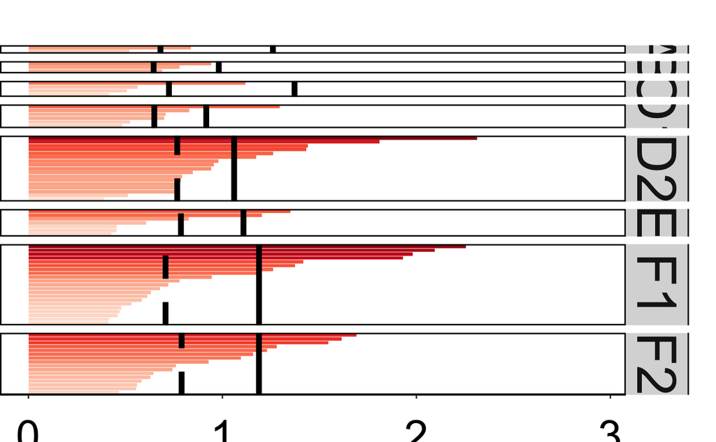

```r
methanogens_coverage_heatmap

#combine the heatmaps with the coverage data
methanogens_combined_plot_pathways_refined<-methanogens_percent_complete_heatmap_pathways_refined +
                                            methanogens_true_false_heatmap_pathways_refined +
                                            methanogens_coverage_heatmap +
                                            plot_layout(ncol = 3, nrow = 1, widths = c(0.1, 0.4, 0.3), guides = "collect")

ggsave("Fig3_Methanogen_metabolism_and_coverage.pdf", height=50, width=35, device="pdf", limitsize = FALSE)
```

# 4. Methanotrophic community analyses

1. As a first step, let’s create a dedicated data frame using the pmo and mmo genes in the presence/absence data from DRAM.

```r
#re-load File S1 if need be
joint_file<-fread("FileS1_DRAM_product_connected_GTDB_taxonomy.tsv", sep = "\t", header = "auto")

#trim data down to putative methanotrophs
methanotrophs <- joint_file %>%
               filter(`Methanogenesis and methanotrophy: methane => methanol, with oxygen (pmo)` == TRUE|
                       `Methanogenesis and methanotrophy: methane => methanol, with oxygen (mmo)` == TRUE)

#create dedicated dataframe for methanotroph data or the lines will not overlay in the coverage bar plot properly
#remove all sites where no methanotroph MAGs were recovered
Coverage_summary_methanotrophs<- Coverage_summary_no_CSWMC %>% filter(!Sample_site == "D2" & !Sample_site == "F1" & !Sample_site == "F2")
```

2. Re-create the percent_gathered and true_falste gathered data frames as was done for the methanogens, but this time use the methanotroph data as the input.

```r
methanotrophs_percent_complete_gathered<-methanotrophs %>%
                           gather(key = Pathway_name, value = Percent_complete,
                                  "3-Hydroxypropionate bi-cycle":"Complex V: V/A-type ATPase, prokaryotes", na.rm=FALSE) %>%
                           select(-c("CAZy: Alpha-galactans": "Sample_site")) %>%
                           mutate(group = case_when(grepl("\\:.*", Pathway_name) ~
                           sub("\\:.*", "", Pathway_name),
                           !grepl("\\:.*", Pathway_name) ~ "Module")) %>% #maintained up to this step
                           mutate(Pathway_name = gsub("Complex I*:","",Pathway_name)) %>% #had to be more specific in filtering
                           mutate(Pathway_name = gsub("Complex IV*.*:","",Pathway_name)) %>%
                           mutate(Pathway_name = gsub("Complex V*.*:","",Pathway_name)) %>%
                           left_join(taxonomy_parsed, by = "genome") #re-add the taxonomic information here

methanotrophs_true_false_gathered<- methanotrophs %>%
                      gather(Pathway_name, Presence_absence,
                             "CAZy: Alpha-galactans":"Sulfur metabolism: thiosulfate => sulfite", na.rm = FALSE) %>%
                      select(-c("3-Hydroxypropionate bi-cycle":"Complex V: V/A-type ATPase, prokaryotes")) %>%
                      mutate(group = case_when(grepl("\\:.*", Pathway_name) ~
                           sub("\\:.*", "", Pathway_name))) %>%
                      mutate(Pathway_name = gsub(".*:","",Pathway_name))
```

3. Add the re-ordering arguments for the facets and trim white space from the ‘Pathway_name’ variable.

```r
#numeric data
methanotrophs_percent_complete_gathered$Pathway_name<-trimws(methanotrophs_percent_complete_gathered$Pathway_name, which = c("left"))

methanotrophs_percent_complete_gathered$Pathway_name = factor(methanotrophs_percent_complete_gathered$Pathway_name,
                                          levels =c(

                                          #Module facet

                                          "Glycolysis (Embden-Meyerhof pathway), glucose => pyruvate",
                                          "Pentose phosphate pathway (Pentose phosphate cycle)",
                                          "Entner-Doudoroff pathway, glucose-6P => glyceraldehyde-3P + pyruvate",
                                          "Citrate cycle (TCA cycle, Krebs cycle)",
                                          "Glyoxylate cycle",
                                          "Reductive pentose phosphate cycle (Calvin cycle)",
                                          "Reductive citrate cycle (Arnon-Buchanan cycle)",
                                          "Dicarboxylate-hydroxybutyrate cycle",
                                          "Hydroxypropionate-hydroxybutylate cycle",
                                          "3-Hydroxypropionate bi-cycle",
                                          "Reductive acetyl-CoA pathway (Wood-Ljungdahl pathway)",
                                          "Acetyl-CoA pathway, CO2 => acetyl-CoA",
                                          "Methanogenesis, CO2 => methane",

                                          #Complex I

                                          "NADH:quinone oxidoreductase, prokaryotes",
                                          "NAD(P)H:quinone oxidoreductase, chloroplasts and cyanobacteria",
                                          "NADH dehydrogenase (ubiquinone) 1 alpha subcomplex",

                                          #Complex II

                                          "Succinate dehydrogenase (ubiquinone)",
                                          "Succinate dehydrogenase, prokaryotes",
                                          "Fumarate reductase, prokaryotes",

                                          #Complex III

                                          "Cytochrome bc1 complex respiratory unit", #what's the difference between first and second?
                                          "Cytochrome bc1 complex",
                                          "Cytochrome bd ubiquinol oxidase",

                                          #Complex IV high affinity

                                          #"Cytochrome bd ubiquinol oxidase", This level is being duplicated, but may not be an issue
                                          "Cytochrome c oxidase, cbb3-type",

                                          #Complex IV low affinity

                                          "Cytochrome c oxidase",
                                          "Cytochrome c oxidase, prokaryotes",
                                          "Cytochrome aa3-600 menaquinol oxidase",
                                          "Cytochrome o ubiquinol oxidase",

                                          #Complex V
                                          "F-type ATPase, prokaryotes and chloroplasts",
                                          "F-type ATPase, eukaryotes",
                                          "V/A-type ATPase, prokaryotes",
                                          "V-type ATPase, eukaryotes"
                                          ))

#categorical data
methanotrophs_true_false_gathered$Pathway_name<-trimws(methanotrophs_true_false_gathered$Pathway_name, which = c("left"))

methanotrophs_true_false_gathered$Pathway_name = factor(methanotrophs_true_false_gathered$Pathway_name,
                                          levels =c(

                                          #CAZy facet

                                          "Polyphenolics",
                                          "Crystalline Cellulose",
                                          "Amorphous Cellulose",
                                          "Xyloglucan",
                                          "Xylans",
                                          "Alpha-mannan",
                                          "Beta-mannan",
                                          "Mixed-Linkage glucans",
                                          "Starch",
                                          "Pectin",
                                          "Arabinan",
                                          "Alpha-galactans",
                                          "Beta-galactan (pectic galactan)",
                                          "Chitin",
                                          "Sulf-Polysachharides",
                                          "Mucin",
                                          "Fucose Cleavage",
                                          "Arabinose cleavage",
                                          "Rhamnose cleavage",

                                          #Nitrogen metabolism

                                          "ammonia => nitrite",
                                          "Bacterial/Archaeal ammonia oxidation",
                                          "Bacterial (aerobic-specific) ammonia oxidation",
                                          "Bacterial (anaerobic-specific) ammonia oxidation",
                                          "nitrite => nitrate",
                                          "nitrate => nitrite",
                                          "nitrite => nitric oxide",
                                          "Dissimilatory nitrite reduction to ammonia (DNRA)",
                                          "nitric oxide => nitrous oxide",
                                          "nitrous oxide => nitrogen",
                                          "nitrogen => ammonia",
                                          "Nitrogen fixation altennative",

                                          #Sulfur metabolism
                                          "dissimilatory sulfate reduction (and oxidation) sulfate => sulfide",
                                          "thiosulfate => sulfite",
                                          "Thiosulfate oxidation by SOX complex, thiosulfate => sulfate",
                                          "tetrathionate => thiosulfate",

                                          #Other reductases

                                          "selenate/Chlorate reduction",
                                          "TMAO reductase",
                                          "mercury reduction",
                                          "arsenate reduction, pt 1",
                                          "arsenate reduction, pt 2",

                                          #Photosynthesis
                                          "Photosystem I",
                                          "Photosystem II",

                                          #Methanogenesis and methanotrophy

                                          "Key functional gene",
                                          "acetate => methane, pt 1",
                                          "acetate => methane, pt 2",
                                          "acetate => methane, pt 3",
                                          "methanol => methane",
                                          "trimethylamine => dimethylamine",
                                          "dimethylamine => monomethylamine",
                                          "monomethylamine => ammonia",
                                          "putative but not defining CO2 => methane",
                                          "methane => methanol, with oxygen (pmo)",
                                          "methane => methanol, with oxygen (mmo)",

                                          #SCFA and alcohol conversions
                                          "pyruvate => acetyl CoA v1",
                                          "pyruvate => acetyl CoA v2",
                                          "pyruvate => acetylCoA f+ formate v3",
                                          "acetate, pt 1",
                                          "acetate, pt 2",
                                          "acetate, pt 3",
                                          "lactate L",
                                          "lactate D",
                                          "Butyrate, pt 1",
                                          "Butyrate, pt 2",
                                          "Propionate, pt 1",
                                          "Propionate, pt 2",
                                          "Alcohol production"
                                          ))
```

5. Create a figure that focuses on the electron transporting and accepting capabilities of putative methanotrophic MAGs.

```r
library(tidyverse)
library(ggtext)
library(patchwork)
library(glue)

heatmap_theme<- theme(panel.grid.major = element_blank(), panel.grid.minor = element_blank(),
               panel.background = element_blank(), axis.line = element_line(colour = "black"),
               axis.text.x = element_text(color = "black", size = 14),
               axis.text.y = element_text(color = "black", size = 14),
               axis.title.x = element_text(color = "black", size = 16, vjust = -3),
               axis.title.y = element_text(color = "black", size = 16, vjust = 6),
               legend.title=element_text(size=16),
               legend.text=element_text(size=14),
               legend.key = element_rect(fill = "white", color = NA),
               plot.title = element_text(size = 18, face = "bold", hjust = 0.5),
               panel.border = element_rect(colour = "black", fill=NA, size=1),
               plot.margin = unit(c(0, 0, 0, 0), "cm"))

methanotrophs_percent_complete_gathered$Sample_site = factor(methanotrophs_percent_complete_gathered$Sample_site,
                                          levels =c("A", "B", "C", "D1", "D2", "E","F1", "F2","CSWMC")) #orders sites that will act as rows in facet

#edit the group variable to account for long names
methanotrophs_percent_complete_gathered$group = factor(methanotrophs_percent_complete_gathered$group,
                                          levels =c("Module", "Complex I", "Complex II", "Complex III",
                                                    "Complex IV High affinity", "Complex IV Low affinity","Complex V")) #order the facets


methanotrophs_percent_complete_heatmap<- methanotrophs_percent_complete_gathered %>%
                    filter(group == "Complex IV High affinity" |
                           group == "Complex IV Low affinity") %>% #this is the additional filtration step
                    mutate(Order = str_replace(string = Order,
                                                pattern = "o__",
                                                replacement = "")) %>%
                    mutate(Order = str_replace(string = Order,
                                                pattern = "(.*)",
                                                replacement = "*\\1*")) %>%
                    mutate(Family = str_replace(string = Family,
                                                pattern = "f__",
                                                replacement = "")) %>%
                    mutate(Family = str_replace(string = Family,
                                                pattern = "(.*)",
                                                replacement = "*\\1*")) %>%
                    mutate(Family = str_replace(string = Family,
                                                pattern = "\\*\\*",
                                                replacement = Order)) %>% #this is to replace any unknown families with their order name
                    mutate(Phylum = str_replace(string = Phylum,
                                                pattern = "p__",
                                                replacement = "")) %>%
                    mutate(Phylum = str_replace(string = Phylum,
                                                pattern = "(.*)",
                                                replacement = "*\\1*")) %>%
                    mutate(Phylum_family_bin = glue("{Phylum}, {Family} ({genome})")) %>%
                    mutate(Phylum_family_bin = as.factor(Phylum_family_bin)) %>%
                    filter(!group == "Module") %>% #filter down to ETC data only
                    filter(!genome == "STE_27") %>%
                    ggplot(aes(x=Pathway_name, y = reorder(Phylum_family_bin, mean_coverage_bin),
                               fill=Percent_complete, na.rm = TRUE))+
                    geom_tile(aes())+
                    facet_grid(Sample_site ~ group,
                               scales = "free", space = "free", labeller = labeller(group = label_wrap_gen(10))) +
                    theme(axis.text.x=element_text(angle=90, hjust=1)) +
                    scale_fill_distiller(palette = "YlGnBu", trans = "reverse", limits = c(1,0))+
                    labs(title = "", x = "", y = "", fill = "% complete") +
                    heatmap_theme +
                    theme(legend.position = "right", legend.direction = "vertical", #set legend position coordinates here
                          legend.key.height= unit(4, 'cm'), legend.key.width = unit(2,"cm"),
                          legend.text = element_text(size = 34),
                          legend.title = element_text(size = 34),
                          strip.background = element_blank(),
                          strip.text.y = element_blank(),
                          strip.text.x = element_text(size = 34),
                          axis.text.x = element_text(color = "black", size = 32),
                          axis.text.y = element_markdown(size = 32, face = "bold"),
                          plot.margin=margin(0,0,0,0)) +
                    guides(guide_colorbar(reverse = TRUE))

#recode the TRUE/FALSE data to presence absence
methanotrophs_true_false_gathered<-methanotrophs_true_false_gathered %>%
                                 mutate(Presence_absence = as.factor(Presence_absence)) %>%
                                 mutate(Presence_absence = recode(Presence_absence, 'TRUE' = "Present", 'FALSE' = "Absent"))

#re-organize the order in which you want to present the landfill cells
methanotrophs_true_false_gathered$Sample_site = factor(methanotrophs_true_false_gathered$Sample_site,
                                          levels =c("A", "B", "C", "D1", "D2", "E","F1", "F2","CSWMC")) #orders sites that will act as rows in facet

#edit the group variable to present them in the proper order for methanogen-centric data
methanotrophs_true_false_gathered$group = factor(methanotrophs_true_false_gathered$group,
                                          levels =c("Methanogenesis and methanotrophy", "CAZy", "SCFA and alcohol conversions",
                                                    "Nitrogen metabolism", "Sulfur metabolism", "Other Reductases","Photosynthesis")) #order facets
```

```r
#put the full order in, just in case you want to present the full suite of data


methanotrophs_true_false_heatmap<- methanotrophs_true_false_gathered %>%
                    mutate(Order = str_replace(string = Order,
                                                pattern = "o__",
                                                replacement = "")) %>%
                    mutate(Order = str_replace(string = Order,
                                                pattern = "(.*)",
                                                replacement = "*\\1*")) %>%
                    mutate(Family = str_replace(string = Family,
                                                pattern = "f__",
                                                replacement = "")) %>%
                    mutate(Family = str_replace(string = Family,
                                                pattern = "(.*)",
                                                replacement = "*\\1*")) %>%
                    mutate(Family = str_replace(string = Family,
                                                pattern = "\\*\\*",
                                                replacement = Order)) %>% #this is to replace any unknown families with order name
                    mutate(Phylum = str_replace(string = Phylum,
                                                pattern = "p__",
                                                replacement = "")) %>%
                    mutate(Phylum = str_replace(string = Phylum,
                                                pattern = "(.*)",
                                                replacement = "*\\1*")) %>%
                    mutate(Phylum_family_bin = glue("{Phylum}, {Family} ({genome})")) %>%
                    mutate(Phylum_family_bin = as.factor(Phylum_family_bin)) %>%
                    mutate(Pathway_name = recode(Pathway_name,
                                                 'methane => methanol, with oxygen (pmo)' = "*pmoA* gene",
                                                 'methane => methanol, with oxygen (mmo)' = "*mmoX* gene")) %>%
                    filter(group == "Methanogenesis and methanotrophy" |
                           group == "Nitrogen metabolism" |
                           group == "Sulfur metabolism") %>%
                    filter(!Pathway_name == "Key functional gene" &
                           !Pathway_name == "acetate => methane, pt 1" &
                           !Pathway_name == "acetate => methane, pt 2" &
                           !Pathway_name == "acetate => methane, pt 3" &
                           !Pathway_name == "dimethylamine => monomethylamine" &
                           !Pathway_name == "dimethylamine => monomethylamine" &
                           !Pathway_name == "methanol => methane" &
                           !Pathway_name == "monomethylamine => ammonia" &
                           !Pathway_name == "putative but not defining CO2 => methane" &
                           !Pathway_name == "trimethylamine => dimethylamine") %>%
                    filter(!genome == "STE_27") %>%
                    ggplot(aes(x=Pathway_name, y = reorder(Phylum_family_bin, mean_coverage_bin), fill=Presence_absence))+
                    geom_tile(aes())+
                    facet_grid(Sample_site ~ group, scales = "free",
                               space = "free", labeller = labeller(group = label_wrap_gen(10))) +
                    theme(axis.text.x=element_text(angle=90, hjust=1)) +
                    scale_fill_manual(values = c("#CCFFFF", "#009933"))+
                    labs(title = "", x = "", y = "", fill = "Function") +
                    heatmap_theme +
                    theme(plot.title = element_text(hjust = 0.7, vjust = -1),
                          legend.position = "right", legend.direction = "vertical", #set legend position coordinates here
                          legend.key.height= unit(4, 'cm'), legend.key.width = unit(2,"cm"),
                          legend.text = element_text(size = 34),
                          legend.title = element_text(size = 34),
                          strip.background = element_blank(),
                          strip.text.y = element_blank(),
                          strip.text.x = element_text(size = 34),
                          axis.text.x = element_markdown(size = 32, color = "black"),
                          axis.text.y = element_blank(),
                          axis.ticks.y = element_blank(),
                          plot.margin=margin(0,0,0,0))

#coverage data for putative methanotrophs
methanotrophs_coverage_heatmap<- methanotrophs_true_false_gathered %>%
                    filter(Sample_site == "A"|
                           Sample_site == "B" |
                           Sample_site == "C" |
                           Sample_site == "D1"|
                           Sample_site == "E") %>%
                    filter(!genome == "STE_27") %>%
                    distinct(genome, .keep_all = TRUE) %>% #need to add this or it will sum repeated coverage values
                    mutate(Order = str_replace(string = Order,
                                                pattern = "o__",
                                                replacement = "")) %>%
                    mutate(Order = str_replace(string = Order,
                                                pattern = "(.*)",
                                                replacement = "*\\1*")) %>%
                    mutate(Family = str_replace(string = Family,
                                                pattern = "f__",
                                                replacement = "")) %>%
                    mutate(Family = str_replace(string = Family,
                                                pattern = "(.*)",
                                                replacement = "*\\1*")) %>%
                    mutate(Family = str_replace(string = Family,
                                                pattern = "\\*\\*",
                                                replacement = Order)) %>% #this is to replace any unknown families with order name
                    mutate(Phylum = str_replace(string = Phylum,
                                                pattern = "p__",
                                                replacement = "")) %>%
                    mutate(Phylum = str_replace(string = Phylum,
                                                pattern = "(.*)",
                                                replacement = "*\\1*")) %>%
                    mutate(Phylum_family_bin = glue("{Phylum}, {Family} ({genome})")) %>%
                    mutate(Phylum_family_bin = as.factor(Phylum_family_bin)) %>%
                    ggplot(aes(x = reorder(Phylum_family_bin, mean_coverage_bin), y = log10(mean_coverage_bin))) +
                    geom_bar(stat = "identity", aes(fill = log10(mean_coverage_bin))) + #add the width argument here
                    facet_grid(rows = vars(Sample_site), scale = "free", space = 'free') +
                    geom_hline(data = Coverage_summary_methanotrophs, aes(yintercept=log10(mean_coverage_site)), size = 2) +
                    geom_hline(data = Coverage_summary_methanotrophs,
                               aes(yintercept=log10(median_coverage_site)), linetype="dashed", size=2) +
                    scale_fill_distiller(palette = "Reds", trans = "reverse")+
                    scale_y_continuous(limits = c(0, log10(857.19452))) + # max coverage for bins in dataset
                    scale_x_discrete(position = "top") +
                    coord_flip() +
                    labs(title = "log10(mean coverage, proxy for abundance)",
                         x = "" , y = "") +
                    heatmap_theme +
                    theme(plot.title = element_text(hjust = 0.5, vjust = -260, size = 30),
                    legend.position = "none", panel.background = element_blank(), axis.line = element_line(colour = "black"),
                    axis.title.x  = element_blank(),
                    axis.text.x = element_text(color = "black", size = 32, vjust = -1),
                    axis.text.y = element_blank(),
                    axis.ticks.y = element_blank(),
                    strip.text.y = element_text(size = 40),
                    strip.text.x = element_text(size = 40))
```

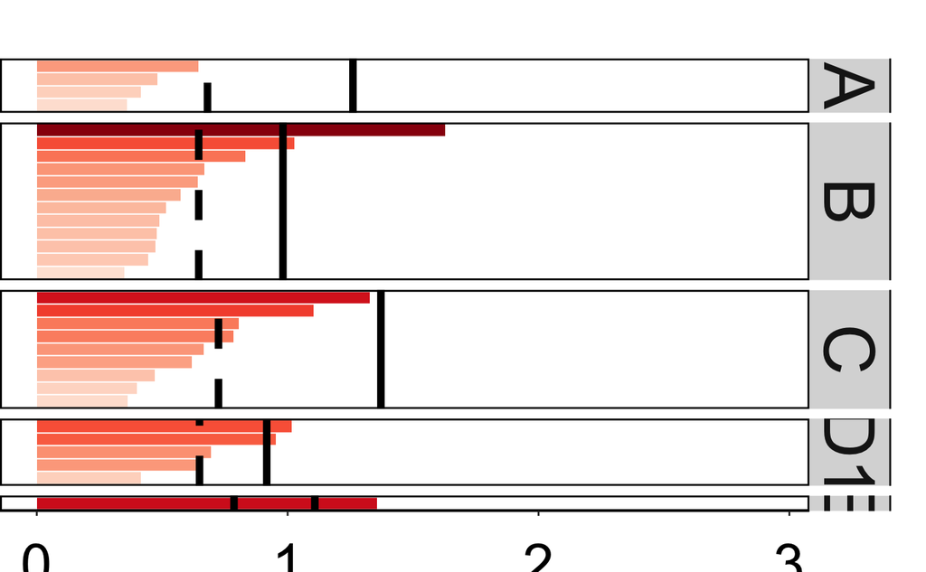

```r
methanotrophs_coverage_heatmap
```

```r
methanotrophs_combined_plot<-methanotrophs_percent_complete_heatmap +
                             methanotrophs_true_false_heatmap +
                             (methanotrophs_coverage_heatmap + theme(legend.position = "none")) +
                             #plot_layout(guides = 'keep') +
                             plot_layout(ncol = 3, nrow = 1, widths = c(0.1, 0.3, 0.1)) +
                             plot_layout(guides = "collect") +
                             plot_annotation(title = "Methanotrophic redox metabolism capacity in a landfill in the NE US",
                                             theme = theme(plot.title = element_text(size = 44, hjust = 0.5, face = "bold")))
```

|  | t | l | b | r |
| --- | --- | --- | --- | --- |
| 1: | 1 | 1 | 1 | 1 |
| 2: | 1 | 2 | 1 | 2 |
| 3: | 1 | 3 | 1 | 3 |

```r
methanotrophs_combined_plot #let's take a quick look even if it is too big to get a sense if everything combined properly

ggsave("Fig5_Methanotrophs_redox_metabolism.pdf", height=36, width=66, device="pdf", limitsize = FALSE)
```